# R Notebook

### Description of our datasets

We used 2 datasets(‘reddit_jokes.json’, ‘stupidstuff.json’)

Before starting testing our hypotesis, we will provide more info about datasets.

In each dataset have Joke.body and it’s own score.

```r
library(jsonlite)
library(fitdistrplus)
```

```r
library(ggplot2)
library(dplyr)
library(stats)
library(stringr)
library(moments)
library(tidytext)
```

Here we prepare our data.(clear empty jokes and add 5 points system for ‘reddit_jokes.json’.

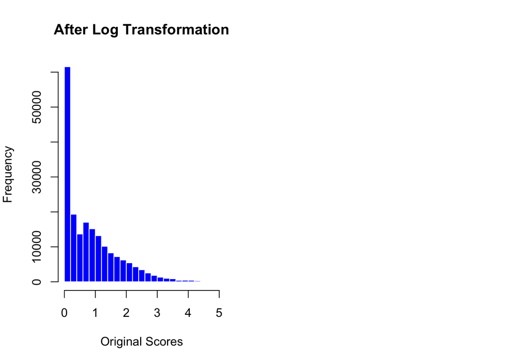

```r
# Read the JSON file
red_data <- fromJSON('reddit_jokes.json')
stuff_data <- fromJSON('stupidstuff.json')
stuff_data <- stuff_data %>% filter(body != "")

if (is.null(red_data$score)) {
  res_score <- red_data
} else {
  res_score <- red_data$score
}

if (!is.null(red_data$score)) {
    log_scores <- log(red_data$score + 1)

    max_log_score <- max(log_scores)
    normalized_scores <- (log_scores / max_log_score) * 5

} else {
    print("Colnum is not found.")
}
par(mfrow = c(1, 2), mar = c(5, 4, 4, 2))

hist(normalized_scores, main = "After Log Transformation", xlab = "Original Scores", col = "blue", border = "white")
```

## Rationale for Using Log Transformation on Grades in ‘reddit_jokes.json’

Despite the fact that the data does not follow an exponential distribution, a log transformation is applied to the grades. This decision is informed by several reasons:

### Reducing Skewness

The distribution of grades is often right-skewed, with a concentration of values at the lower end and a long tail towards the higher end. A log transformation can help reduce this skewness, making the data more symmetric and, hence, more amenable to analysis techniques that assume normality.

### Handling Outliers

Log transformation dampens the effect of outliers. Given that higher grades can vary widely and have a disproportionate effect on the mean, transforming the data reduces the impact of these extreme values.

### Normalizing Variance

Variance in the data often increases with the value of the grades. The log transformation can help stabilize the variance across different ranges of scores, which is a desirable property for many statistical analyses.

### Proportional Scaling

A log transformation ensures that changes in the transformed data represent proportional changes in the original data, which can be more intuitive for understanding differences between grades.

```r
jokes_with_rating_5 <- filter(stuff_data, rating == 5)

# Randomly select 5 jokes from those with a rating of 5
random_5_jokes <- sample_n(jokes_with_rating_5, 5)

cat("Random 5 Jokes with Rating 5:\n")
```

```
## Random 5 Jokes with Rating 5:
```

```r
for(i in 1:nrow(random_5_jokes)) {
  cat(sprintf("%d. %s\n\n", i, random_5_jokes$body[i]))
}
```

```
## 1. Come and listen to a story 'bout a man named Jed,
## A poor college kid, barely kept his family fed,
## But one day he was talking to a recruiter,
## Who said, "they pay big bucks if ya work on a computer..."
##
## UNIX, that is... CRTs... Workstations...
##
## Well, the first thing ya know ol' Jed's an Engineer.
## The kinfolk said "Jed, move away from here".
## They said "Arizona is the place ya oughta be",
## So he bought a box of donuts and he moved to Ahwatukee...
##
## Intel, that is... dry heat... no amusement parks...
##
## On his first day at work, they stuck him in a cube.
## Fed him mo' donuts and sat him at a tube.
## Said "yo project's outta budget, but we know just what to do.
## Instead of 40 hours, we'll work you 52!"
##
## OT, that is... unpaid... mandatory...
##
## The weeks rolled by and things were looking bad.
## Schedules were slipping and the boss was getting mad.
## They called another meeting and decided on a fix.
## The answer was simple... "We'll work him sixty-six!"
##
## Tired, that is... stressed out... no social life...
##
## Months turned to years and his hair was turning grey.
## Jed worked hard while his life just slipped away.
## Waiting to retire when he turned to 64,
## Instead he got a call and escorted out the door.
##
## Laid off, that is... lead hand shake... unemployed...
##
## Now the moral of the story is listen to what you're told,
## Companies will use you and discard you when you're old.
## So gather up your friends and start your own firm,
## Beat the competition, watch the bosses squirm.
##
## Millionaires, that is... Bill Gates... Steve Jobs...
##
## Y'all come back now... ya hear'
##
## 2. There was once a young lawyer, age 29, who was on his way to work when he was hit by a bus. He goes to heaven and meet's St. Peter and pleads, "I am much to young to die, there must be a mistake!". St. Peter thinks about this for a moment and goes out the back to consult with God. Ten minutes …
##
## 3. The thing that terrifies me the most is that someone might hate me as much as I loathe you.
##
## 4. Yo mama so stupid she missed the 44 bus so she just took the 22 bus twice
##
## 5. There was this bloke who had a dog which he was attempting to train, but alas had very little success. He was on the verge of despair when he happened across a very charismatic American evangelist. He unburdened his soul to the American, who promptly informed him to leave the dog with him, and…
```

#### Top 5 jokes from ‘reddit_jokes.json’:

```r
top_5_jokes_by_score <- red_data %>%
  arrange(desc(score)) %>%
  head(5)

# Merge titles and bodies, and remove "/r/"
merged_jokes <- top_5_jokes_by_score %>%
  mutate(joke_text = paste(title, body, sep = "\n")) %>%
  mutate(joke_text = gsub("/r/", "", joke_text))

# Output the merged jokes
cat("Top 5 Jokes by Score (Merged and without /r/):\n")
```

```
## Top 5 Jokes by Score (Merged and without /r/):
```

```r
for(i in 1:nrow(merged_jokes)) {
  cat(sprintf("%d. %s\n\n", i, merged_jokes$joke_text[i]))
}
```

```
## 1. Breaking News: Bill Gates has agreed to pay for Trump's wall
## On the condition he gets to install windows.
##
##
##
##
## 2. I found a place where the recycling rate is 98%
## Jokes
##
## 3. Steve jobs would have been a better president than Donald Trump.
## But its a silly comparison really, its like comparing apples to oranges.
##
## 4. My girlfriend told me to take the spider out instead of killing it.
## We went and had some drinks. Cool guy. Wants to be a web developer.
##
## 5. For every upvote this gets, my girlfriend and I will try one thrust of anal sex.
## Please don't upvote. Her strap-on is huge.
```

#### Categories in ‘stupidstuff.json’:

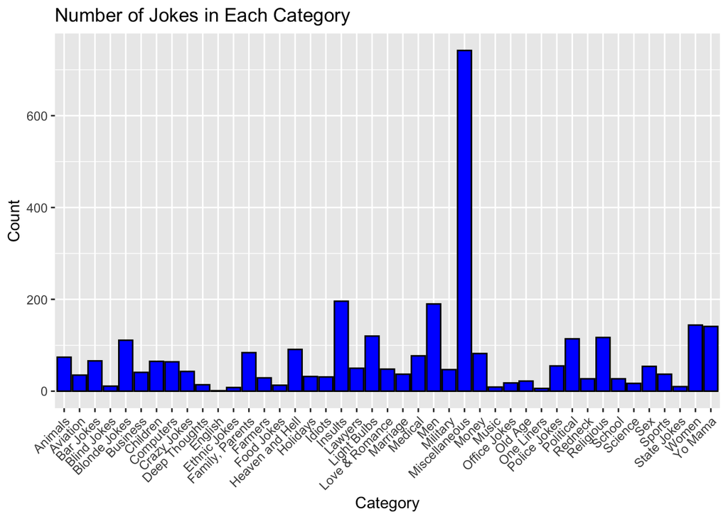

```r
ggplot(stuff_data, aes(x=category)) +
    geom_histogram(stat="count", fill="blue", color="black") +
    theme(axis.text.x = element_text(angle = 45, hjust = 1)) +
    labs(title="Number of Jokes in Each Category",
         x="Category",
         y="Count")
```

### Testing distribution of scores

$H_0$: The jokes rating has exponential distribution. $H_1$: The jokes rating doesn’t have exponential distribution.

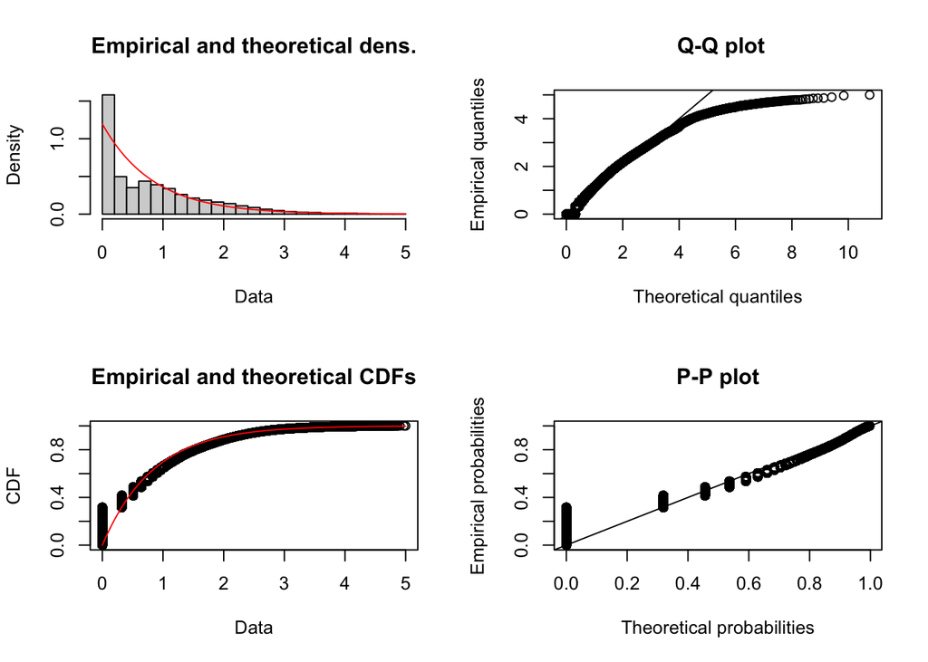

```r
fdist <- fitdist(normalized_scores, "exp")

plot(fdist)
```

```r
gof <- gofstat(fdist)
print(gof)
```

```
## Goodness-of-fit statistics
##                                 1-mle-exp
## Kolmogorov-Smirnov statistic    0.3164228
## Cramer-von Mises statistic   2241.0706859
## Anderson-Darling statistic            Inf
##
## Goodness-of-fit criteria
##                                1-mle-exp
## Akaike's Information Criterion  319294.8
## Bayesian Information Criterion  319305.0
```

```r
ks.test(normalized_scores, "pnorm", mean = mean(normalized_scores), sd = sd(normalized_scores))
```

```
##
##  Asymptotic one-sample Kolmogorov-Smirnov test
##
## data:  normalized_scores
## D = 0.17174, p-value < 2.2e-16
## alternative hypothesis: two-sided
```

## Diagnostic Plots for Goodness-of-Fit Assessment

The uploaded image displays a series of diagnostic plots commonly employed to evaluate the goodness-of-fit between a statistical distribution and a set of data points. Specifically, these plots compare empirical data (data points) to a theoretical exponential distribution. Each plot serves a distinct purpose:

## Q-Q (Quantile-Quantile) Plot

Used to compare quantiles of empirical data distribution with those of the theoretical distribution (exponential in this case). Points aligning with the reference line indicate agreement with the theoretical distribution. The image shows significant deviation, especially for higher quantiles, suggesting a potential mismatch with an exponential distribution.

## P-P (Probability-Probability) Plot

Similar to the Q-Q plot, this plot compares cumulative probabilities. If the empirical data distribution matches the theoretical distribution, points should lie on the diagonal line. Most data points in the plot are near the diagonal, indicating a reasonable fit for most of the data range, with some deviations.

**Overall Assessment:** These plots collectively suggest that the exponential distribution may not be the best fit for the data, particularly at higher quantiles (as indicated by the Q-Q plot) and possibly in the tail of the CDF plot. The P-P plot suggests a reasonable fit for the lower to mid-range of the data. It’s essential to consider the goodness-of-fit test (gof) results, not visible in the image, for a more comprehensive statistical assessment.

#### Conclusion for first hypothesis:

After all test. We can reject $H_0$. So our scores doesn’t have exponential distribution.

#### Testing if joke’s quality depends on length

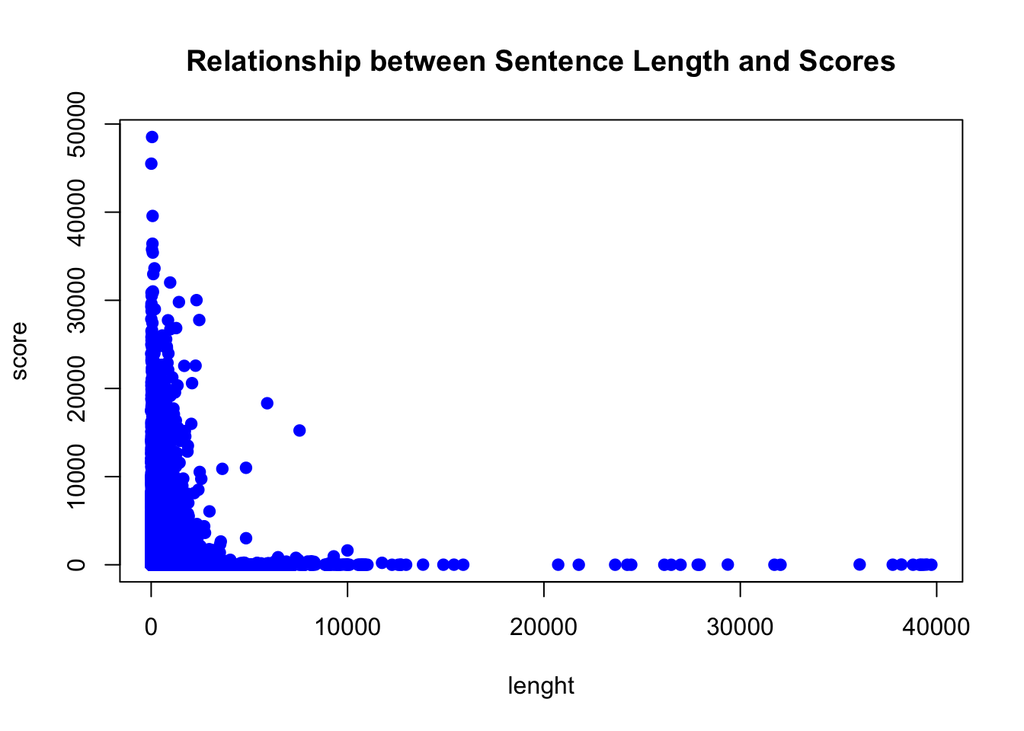

```r
if (is.null(stuff_data$body)) {
  res_body <- red_data
} else {
  res_body <- red_data$body
}


lengths_of_sentences <- nchar(res_body)


plot(lengths_of_sentences, res_score, main = "Relationship between Sentence Length and Scores", xlab = "lenght", ylab = "score", pch = 19, col = "blue")
```

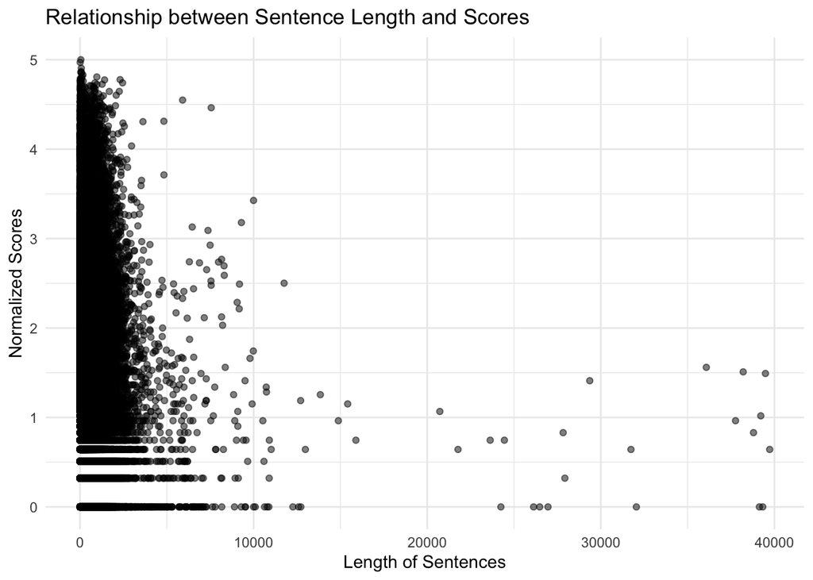

```r
# Assuming 'data' is a data frame that contains the 'lengths_of_sentences' and 'normalized_scores' columns
ggplot(red_data, aes(x = lengths_of_sentences, y = normalized_scores)) +
  geom_point(alpha = 0.5) + # Adjust alpha for point transparency if there's overplotting
  labs(title = "Relationship between Sentence Length and Scores",
       x = "Length of Sentences",
       y = "Normalized Scores") +
  theme_minimal()
```

### Linear regression

```r
model <- lm(normalized_scores ~ lengths_of_sentences, data = red_data )

summary(model)
```

```
##
## Call:
## lm(formula = normalized_scores ~ lengths_of_sentences, data = red_data)
##
## Residuals:
##     Min      1Q  Median      3Q     Max
## -8.7863 -0.7976 -0.1961  0.4774  4.1963
##
## Coefficients:
##                       Estimate Std. Error t value Pr(>|t|)
## (Intercept)          7.942e-01  2.109e-03  376.65   <2e-16 ***
## lengths_of_sentences 2.032e-04  3.501e-06   58.04   <2e-16 ***
## ---
## Signif. codes:  0 '***' 0.001 '**' 0.01 '*' 0.05 '.' 0.1 ' ' 1
##
## Residual standard error: 0.8747 on 194551 degrees of freedom
## Multiple R-squared:  0.01702,    Adjusted R-squared:  0.01701
## F-statistic:  3369 on 1 and 194551 DF,  p-value: < 2.2e-16
```

###Depending on the change in length by 1 value, the score changes to 2.032e-04. The standard error is very small (which is very good) and the p value is very close to zero, which means that there is no random dependence. The maximum and minimum deviation is 4 and -8, respectively. The estimate depends on the length by only 0.01702.

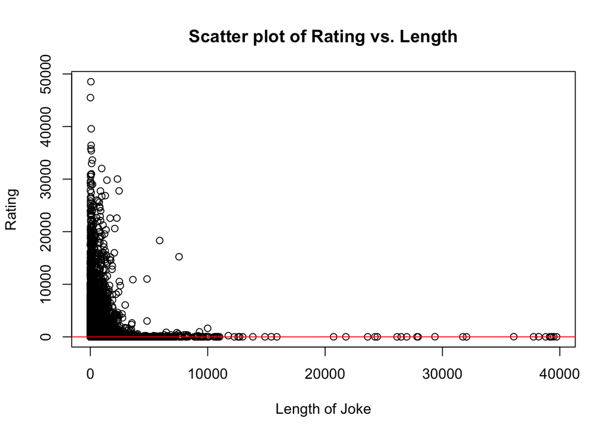

```r
# Scatter plot of Rating against Length
plot(lengths_of_sentences, res_score,
     main = "Scatter plot of Rating vs. Length",
     xlab = "Length of Joke", ylab = "Rating")

# Add the regression line to the plot
abline(model, col = "red")
```

```r
# Show the plot
```

### Testing the quality depends on category?

But before doing this calculation, we will exclude category “Miscellaneous”.

#### ANOVA Test

We used the Analysis of Variance (ANOVA) test because it allows us to determine if there are significant differences in joke ratings among multiple categories. ANOVA assesses whether the variation in ratings is due to the categories themselves rather than random chance. This is relevant to test whether the quality of jokes depends on their category, which is the focus of your hypotheses.

```r
filtered_data <- stuff_data %>%
  filter(category != "Miscellaneous")

jokes_data <- filtered_data %>% select(rating, category)
result <- aov(rating ~ category, data = jokes_data)
summary(result)
```

```
##               Df Sum Sq Mean Sq F value  Pr(>F)
## category      41    101   2.470   1.797 0.00149 **
## Residuals   2416   3322   1.375
## ---
## Signif. codes:  0 '***' 0.001 '**' 0.01 '*' 0.05 '.' 0.1 ' ' 1
```

#### Conclusion to third hypothesis

The ANOVA results reveal that the “category” factor has a statistically significant effect on joke ratings (F(41, 2416) = 1.797, p = 0.00149, **). This small p-value (p < 0.05) indicates strong evidence against the null hypothesis.

Therefore, we reject the null hypothesis (H0) and conclude that the quality (rating) of a joke indeed depends on its category. In other words, there are significant differences in joke ratings among the categories. The variation in ratings is not solely due to random chance but is influenced by the category of the joke.

```r
# Sum of points of each category
category_sum_points <- filtered_data %>%
  group_by(category) %>%
  summarize(sum_points = sum(rating))
print(category_sum_points)
```

```
## # A tibble: 42 × 2
##    category      sum_points
##    <chr>              <dbl>
##  1 Animals            199.
##  2 Aviation           110.
##  3 Bar Jokes          225.
##  4 Blind Jokes         35.7
##  5 Blonde Jokes       391.
##  6 Business           139.
##  7 Children           225.
##  8 Computers          221.
##  9 Crazy Jokes        141.
## 10 Deep Thoughts       50.8
## # ℹ 32 more rows
```

First - data cleaning

```r
reddit_jokes <- fromJSON('reddit_jokes.json')
stp_jokes <- fromJSON('stupidstuff.json')
stop_words <- data.frame(word = tolower(readLines("stop_words_mod.txt")))
colnames(stop_words)[colnames(stop_words) == "rating"] <- "score"
splitted_stop_words <- c(stop_words, "s")

# remove id column
reddit_jokes <- reddit_jokes[, -which(names(reddit_jokes) == "id")]
stp_jokes <- stp_jokes[, -which(names(stp_jokes) == "id")]
stp_jokes <- stp_jokes[, -which(names(stp_jokes) == "category")]

#merge title and body columns
reddit_jokes$body <- paste(reddit_jokes$title, reddit_jokes$body)

#remove title column
reddit_jokes <- reddit_jokes[, -which(names(reddit_jokes) == "title")]

#remove useless symols
reddit_jokes$body <- gsub("\\?|\\,|\\.|!|“|\"|”|…|:", "", reddit_jokes$body)
reddit_jokes$body <- gsub("\n\n|\n| - ", " ", reddit_jokes$body)
stp_jokes$body <- gsub("\\?|\\,|\\.|!|“|\"|”|…|:|'", "", stp_jokes$body)
stp_jokes$body <- gsub("\n\n|\n| - |  ", " ", stp_jokes$body)

#change all characters to lower case
reddit_jokes$body <- tolower(reddit_jokes$body)
stp_jokes$body <- tolower(stp_jokes$body)

stop_words_pattern <- paste0("\\b", paste(stop_words, collapse = "\\b|\\b"), "\\b")

# Filter out stop words and words with length smaller than 3
reddit_jokes <- reddit_jokes %>%
  mutate(body_filtered = str_replace_all(body, stop_words_pattern, "")) %>%
  mutate(body_filtered = str_replace_all(body_filtered, "\\b\\w{1,2}\\b", ""))

stp_jokes <- stp_jokes %>%
  mutate(body = str_replace_all(body, stop_words_pattern, "")) %>%
  mutate(body = str_replace_all(body, "\\b\\w{1,2}\\b", ""))

colnames(stp_jokes)[colnames(stp_jokes) == "rating"] <- "score"
stp_jokes <- stp_jokes[which(stp_jokes$body != ""), ]
```

But to make classifier we need to divide our jokes in two or more types. We will divide in types: funny and goofy. Class “funny” will contain jokes which has score higher than 2.5 and “goofy” which lower or equal to 2.5. May be this approach was good if we have the symetric distribution, but in our case data has very big skewness:

```r
skewness(reddit_jokes$score)
```

```
## [1] 17.75724
```

So we need to divide our data set in two approximately equal parts. We decided to take such intervals: from 0 to 0.5 is “bad joke” and from 0.5 to 5 is “good joke”. We can have such classes, because if we look at the general situation on reddit or on the Internet as a whole: we will notice that after a comment gains reactions (in our case, a rating) more than a certain critical value, its popularity grows faster (very similar to the network effect in the economy) . Therefore, we can divide our jokes into approximately the same number of groups to make our model more accurate in identifying the category, as this effect extends to jokes as well.

However, there is a problem: our jokes has rating

```r
cat("from", min(reddit_jokes$score),"to", max(reddit_jokes$score))
```

```
## from 0 to 48526
```

so we need to scale them (what we have done in previous sections). We will use logarithmic scaling

```r
reddit_jokes$score <- log(reddit_jokes$score + 1)
reddit_jokes$score <- scales::rescale(reddit_jokes$score, to = c(0, 5))
```

Now lets divide jokes to categories

```r
reddit_jokes$score <- ifelse(reddit_jokes$score > 0.5, "funny", "goofy")
stp_jokes$score <- ifelse(stp_jokes$score > 0.5, "funny", "goofy")
```

```r
cat("Funny:", table(reddit_jokes$score[reddit_jokes$score == "funny"]), "\n")
```

```
## Funny: 113645
```

```r
cat("Not funny:", table(reddit_jokes$score[reddit_jokes$score == "goofy"]))
```

```
## Not funny: 80908
```

So now we can start to create a model:

Firstly make some neccessary preparation before set-uping model

```r
reddit_jokes <- data.frame(reddit_jokes)
reddit_jokes <- subset(reddit_jokes, select = -body_filtered)
```

```r
splitted_jokes <- unnest_tokens(reddit_jokes, "splitted", "body", token = "words")
split_data <- split(splitted_jokes, splitted_jokes$score)
```

```r
container <- data.frame(splitted = character(0), types = character(0))

for (score in names(split_data)) {
  group <- data.frame(splitted = split_data[[score]], types = score)
  container <- bind_rows(container, group)
}
```

```r
funny_df <- data.frame(splitted = split_data[["funny"]])
goofy_df <- data.frame(splitted = split_data[["goofy"]])

funny_count <- funny_df %>% count(split_data[["funny"]], sort = TRUE)
goofy_count <- goofy_df %>% count(split_data[["goofy"]], sort = TRUE)
```

```r
tidy_t <- unnest_tokens(stp_jokes, "splitted", "score", token = "words")
```

```r
naiveBayes <- setRefClass("naiveBayes",

       fields = list(
         fit_model = "data.frame",
         word_count = "data.frame"
       ),
       methods = list(
                    fit = function(X, y)
                    {
                      tidy_t <- unnest_tokens(X, "splitted", "score", token = "words")
                      tidy_text <- tidy_t %>% filter(!splitted %in% splitted_stop_words)

                      .self$word_count <- tidy_text %>% count(splitted, sort = TRUE)

                      df_for_words <- data.frame(matrix(0, nrow = nrow(.self$word_count['splitted']), ncol = length(y)))

                      colnames(df_for_words) <- y
                      rownames(df_for_words) <- word_count$splitted

                      for(i in 1:nrow(df_for_words)) {
                        if (rownames(df_for_words[i, ]) %in% funny_count$splitted) {
                          df_for_words[i, 1] = 1
                        }
                        if (rownames(df_for_words[i, ]) %in% goofy_count$splitted) {
                          df_for_words[i, 2] = 1
                        }
                      }
                      .self$fit_model <- df_for_words
                    },

                    predict = function(message)
                    {
                      message_list <- list(strsplit(tolower(message), " ")[[1]])
                      df_message <- data.frame(matrix(0, nrow=length(message_list[[1]]), ncol = 2))
                      all_words <- sum(.self$word_count$n)+length(message_list[[1]])
                      all_funny_words = sum(funny_count$n)
                      all_goofy_words = sum(goofy_count$n)

                      funny_prob = all_funny_words/all_words
                      goofy_prob = all_goofy_words/all_words

                      colnames(df_message) <- c('funny', 'goofy')
                      rownames(df_message) <- message_list[[1]]

                      for (i in 1:nrow(df_message)) {
                        if (rownames(df_message[i, ]) %in% rownames(.self$fit_model)) {
                          if (rownames(df_message[i, ]) %in% funny_count$splitted) {
                            df_message[i, 1] = (funny_count[which(funny_count$splitted == rownames(df_message[i, ])), 3] + 1)/(all_funny_words+all_words)
                          } else {
                            df_message[i, 1] = 1/(all_funny_words+all_words)
                          }
                          if (rownames(df_message[i, ]) %in% goofy_count$splitted) {
                            df_message[i, 2] = (goofy_count[which(goofy_count$splitted == rownames(df_message[i, ])), 3] + 1)/(all_goofy_words+all_words)
                          } else {
                            df_message[i, 2] = 1/(all_goofy_words+all_words)
                          }
                        } else {
                            df_message[i, 1] = 1/(all_goofy_words+all_words)
                            df_message[i, 2] = 1/(all_goofy_words+all_words)
                        }
                      }

                      new_row = list(funny_prob, goofy_prob)
                      df_message = rbind(df_message, new_row)

                      prob_for_message <- apply(df_message, 2, prod)

                      return(names(prob_for_message[which(prob_for_message == max(prob_for_message))]))
                    }

))

model = naiveBayes()
temp_column <- reddit_jokes$body
reddit_jokes$body <- reddit_jokes$score
reddit_jokes$score <- temp_column

colnames(reddit_jokes)[1] <- "score"
colnames(reddit_jokes)[2] <- "body"

model$fit(reddit_jokes, c("funny", "goofy"))
```

### Conclusion

The analysis revealed that the distribution of jokes’ quality ratings does not follow an exponential distribution. This suggests that the ratings of jokes do not exhibit the typical characteristics of an exponential distribution, such as rapidly decreasing probabilities with increasing ratings.

A significant finding of the research is that the quality of jokes is dependent on their category. The category or topic of a joke plays a crucial role in determining its quality. The analysis, as supported by ANOVA, indicated that there are significant differences in joke ratings among different joke categories. This suggests that the variation in ratings is not solely due to random chance but is influenced by the category of the joke.

It’s important to remember that the accuracy of joke analysis results is always limited by subjectivity and the differences in people’s tastes. So when interpreting joke data, it’s important to be cautious and understand that these are just ratings that reflect the tastes and preferences of a specific audience.

Analyzing joke data can provide general insights into trends and patterns, but it can’t always accurately predict which joke will appeal to each individual.